# BLS Wichita Software Developer Salaries

## Goals & Motivation

The health of Wichita’s professional software development community is often debated but not often researched. Each of us in the community personally experience only a small slice of overall picture, and undoubtedly this personal experience informs our opinions about the whole.

Two underlying questions often form the foundation of such discussions: 1) Does Wichita have a developer shortage? 2) Do developers in Wichita earn a reasonable compensation?

These are both complicated questions. What does “developer” mean in this context? How many developers constitutes a shortage? What is reasonable compensation? Should cost of living differences be incurred by the employee or the employer?

But despite these nuances, both questions are inherently *empirical*. Individual perspectives may lead to different interpretations, but all parties in the discussion should, at a minimum, be able to agree on a shared set of basic facts.

## Data Sources

### Occupational Employment Statistics Survey

The Occupational Employment Statistics (OES) survey conducted by the Bureau of Labor Statistics provides the primary data set for this analysis. This survey estimates job counts and salary data by Metropolitan Statistical Area (MSA) and by job category.

> The OES survey is a cooperative effort between BLS and the State Workforce Agencies (SWAs). BLS funds the survey and provides the procedures and technical support, while the State Workforce Agencies collect most of the data. OES estimates are constructed from a sample of about 1.2 million establishments. Each year, two semiannual panels of approximately 200,000 sampled establishments are contacted, one panel in May and the other in November. Responses are obtained by mail, Internet or other electronic means, email, telephone, or personal visit. The May 2017 estimates are based on responses from six semiannual panels collected over a 3-year period: May 2017, November 2016, May 2016, November 2015, May 2015, and November 2014. The overall national response rate for the six panels, based on the 50 states and the District of Columbia, is 72 percent based on establishments and 68 percent based on weighted sampled employment. The unweighted sampled employment of 82 million across all six semiannual panels represents approximately 58 percent of total national employment.

See https://www.bls.gov/oes/current/oes_48620.htm for the current Wichita data. Note that the 2018 survey is used below whereas the link points to an evergreen current version. I.e., “current” will need to be replaced with “2018” in the future.

Since this is a survey, not a complete census, sampling *error* limits the precision of the estimates. This error can be measured. There could also be sampling *bias* resulting from the survey design and implementation which cannot be directly measured. These sources of error should inform any conclusions drawn from the data.

As an establishment survey, the OES survey groups remote workers and local workers together into the establishment. [^1] This means that remote workers will be included in the establishment’s MSA, regardless of the worker’s physical location.

#### Job Categories

Four job categories are included in the base analysis:

1. [Computer Programmers](https://www.bls.gov/oes/current/oes151131.htm)
2. [Software Developers, Applications](https://www.bls.gov/oes/current/oes151132.htm)
3. [Software Developers, Systems Software](https://www.bls.gov/oes/current/oes151133.htm)
4. [Web Developers](https://www.bls.gov/oes/current/oes151134.htm)

These categories comprise the entirety of the broad (5-digit) “Software Developers and Programmers” category and were chosen in an attempt to examine wage characteristics of workers who develop software as their primary job activity.

Job category selection is context dependent, and there is no single “right” grouping. By selecting these categories, we exclude related categories such as “Database Administrators”, “Computer Systems Analysts”, etc. This decision can materially affect the results of the analysis. [^2] Users are encouraged to adjust the job category list to fit their specific questions.

### Regional Price Parity Indexes

Regional Price Parity (RPP) indexes are used to compare the cost of living in different MSAs. These estimates are sourced from the Bureau of Economic Analysis (BEA) at https://www.bea.gov/data/prices-inflation/regional-price-parities-state-and-metro-area. Note that the RPP dates do not align perfectly with the OES survey dates. While not ideal, this is not expected to introduce meaningful error since the *relative* cost of living differences are not likely to change substantially over a 1-2 year window.

## Analysis

### How many developers are in Wichita?

```r
location_data %>%
  filter(Location %in% peer_locations) %>%
  select(Location, TotalEmployment, Per1000Jobs) %>%
  mutate(TotalEmployment = comma(TotalEmployment)) %>%
  mutate(Per1000Jobs = force_digits(Per1000Jobs, 1)) %>%
  arrange(desc(Per1000Jobs))
```

| Location | TotalEmployment | Per1000Jobs |
| --- | --- | --- |
| Kansas City, MO-KS | 16,760 | 15.8 |
| Omaha-Council Bluffs, NE-IA | 7,540 | 15.4 |
| Des Moines-West Des Moines, IA | 5,330 | 14.4 |
| Oklahoma City, OK | 4,650 | 7.5 |
| Tulsa, OK | 2,500 | 5.8 |
| Wichita, KS | 1,600 | 5.4 |

where “developer” is defined as one of the following:

```r
occupations
```

```
## [1] "Web Developers"
## [2] "Software Developers, Applications"
## [3] "Software Developers, Systems Software"
## [4] "Computer Programmers"
```

### What % of Wichita’s labor market is the dev community?

% of employment:

```r
valueToPctStr(pull(location_data %>% filter(Location == 'Wichita, KS'), TotalEmployment) / wichita$TotalEmployment)
```

```
## [1] "0.5%"
```

% of total salary dollars:

```r
valueToPctStr(pull(location_data %>% filter(Location == 'Wichita, KS'), TotalSalary) / wichita$TotalSalary)
```

```
## [1] "1.0%"
```

### Does Wichita have a dev shortage?

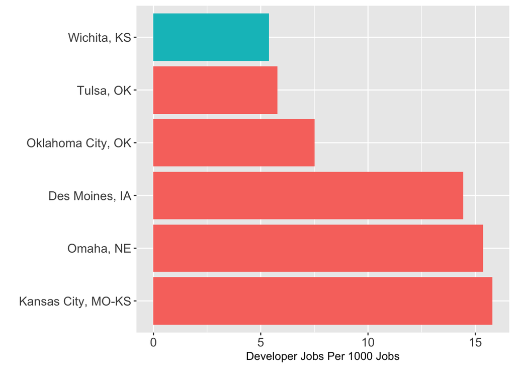

```r
plot_per1000ByLocation
```

Yes. Wichita’s developer density is:

```r
ict_density <- location_data %>% filter(Location == 'Wichita, KS') %>% pull(Per1000Jobs)
nat_density <- location_data %>% filter(Location == 'National') %>% pull(Per1000Jobs)

ict_density_comp <- ict_density / nat_density
percent(ict_density_comp) # ICT density as a % of national density
```

```
## [1] "46.8%"
```

### How much economic value would addressing this shortage generate?

```r
ict_multiplier_to_match_national <- 1 / ict_density_comp
ict_base_data <- location_data %>% filter(Location == 'Wichita, KS')
ict_current_devs <- ict_base_data %>% pull(TotalEmployment)

incremental_devs <- (ict_multiplier_to_match_national - 1) * ict_current_devs
incremental_devs
```

```
## [1] 1818.111
```

```r
ict_mean_dev_salary <- ict_base_data %>% pull(MeanSalary)
ict_mean_dev_salary
```

```
## [1] 85734.62
```

```r
ict_mean_dev_salary * incremental_devs / 1000000
```

```
## [1] 155.8751
```

### How do the salary ranges compare to the salary survey?

There is no perfect way to compare the ranges, despite having percentile information from BLS, because we can’t aggregate them into our overall developer category. We could compare by role – web developer, for example – but that increases the estimation error and probably creates more problems than it solves.

For a simple comparison, the mean salary from the salary surveys were $68,640 and $77,380 for 2017 and 2018, respectively, compared to a mean salary from the BLS data of:

```r
mean_salary <- location_data %>% filter(Location == wichita_area_name) %>% pull(MeanSalary)
mean_salary
```

```
## [1] 85734.62
```

This represents a difference of

```r
valueToPctStr(mean_salary / 68640 - 1)
```

```
## [1] "24.9%"
```

and

```r
valueToPctStr(mean_salary / 77380 - 1)
```

```
## [1] "10.8%"
```

relative to the 2017 and 2018 survey figures, respectively.

### How does the average Wichita dev salary compare to regional peers without any RPP adjustments?

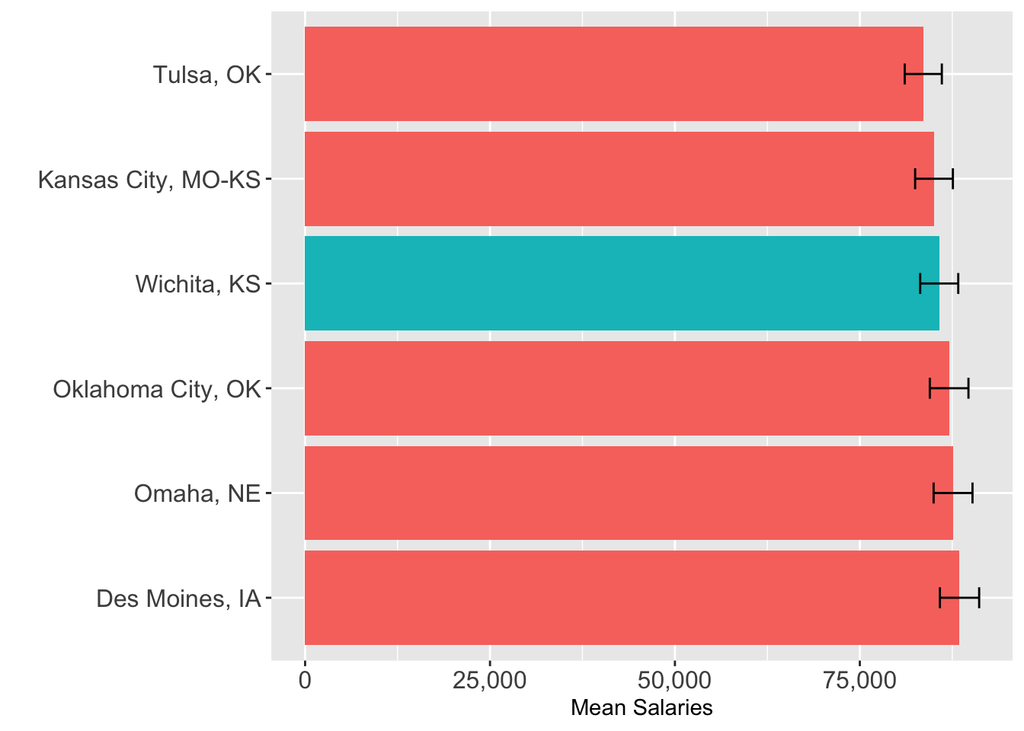

```r
plot_salaryByLocation
```

2017 data for additional context:

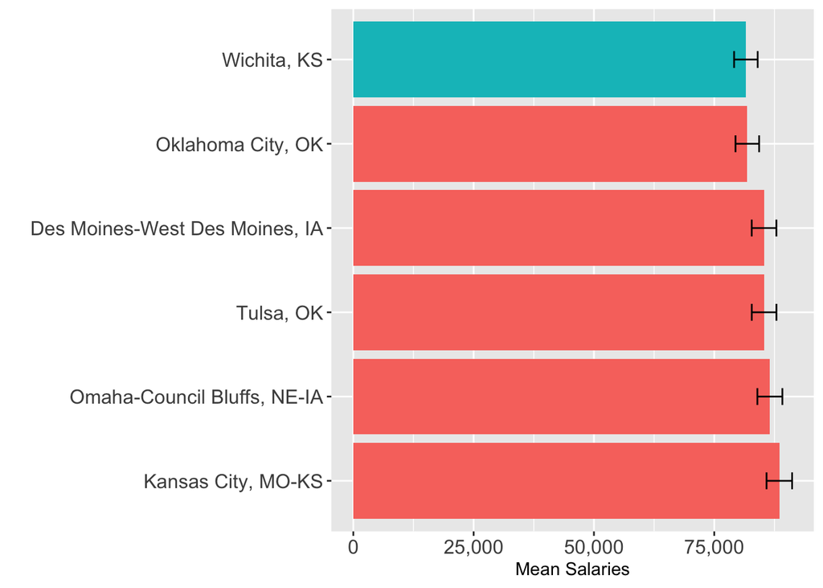

```r
env2017 <- new.env()
load('salaryByLocation2017.RData', envir=env2017)
get('plot_salaryByLocation', envir=env2017) + scale_y_continuous(label=comma) + theme(axis.text = element_text(size=12))
```

### How does the average Wichita dev salary compare to regional peers, RPP adjusted?

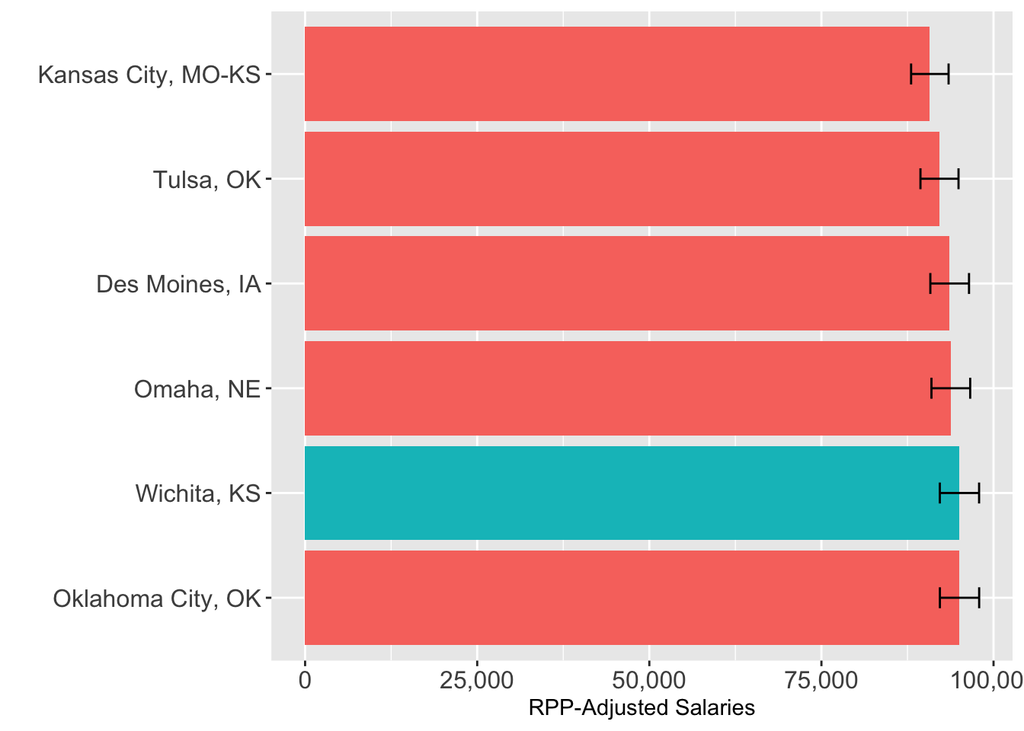

```r
plot_rppAdjustedSalaryByLocation
```

Note the RPP values are from 2016 while the salary values are from 2018. Since we are comparing on an MSA relative basis, this difference is negligible.

2017 data for additional context:

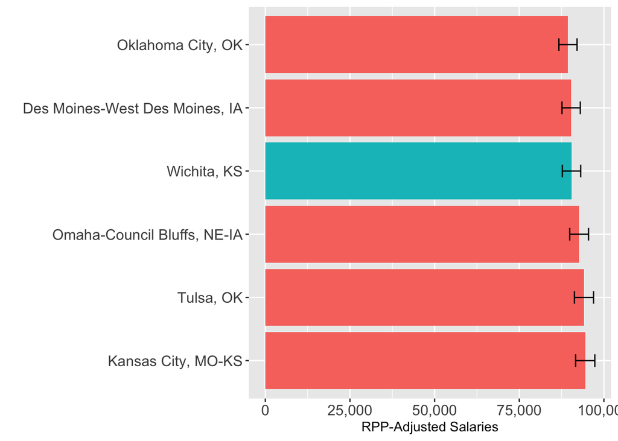

```r
load('rppAdjustedSalaryByLocation2017.RData', envir=env2017)
get('plot_rppAdjustedSalaryByLocation', envir=env2017) + scale_y_continuous(label=comma) + theme(axis.text = element_text(size=12))
```

### How does Wichita compare to tech hubs?

#### Developer Density

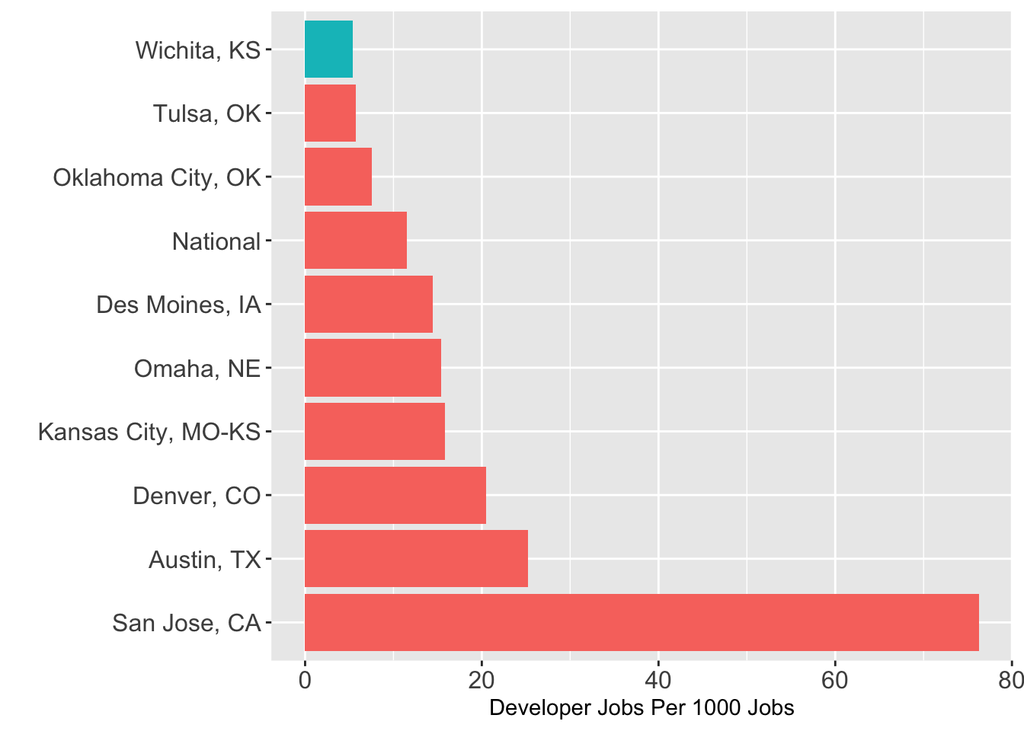

```r
plot_per1000ByLocation_all
```

#### Salary (no adjustments)

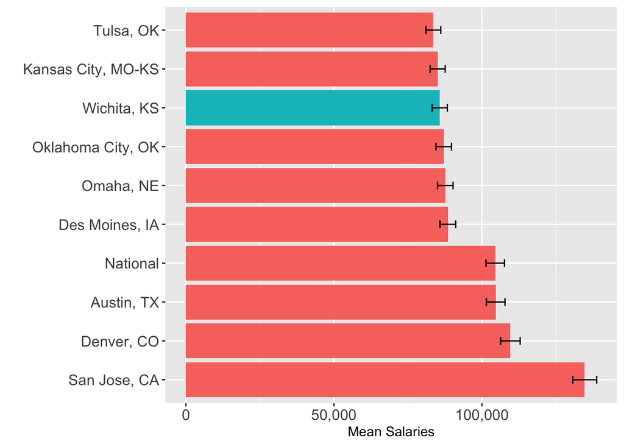

```r
plot_salaryByLocation_all
```

#### Salary (RPP-adjusted)

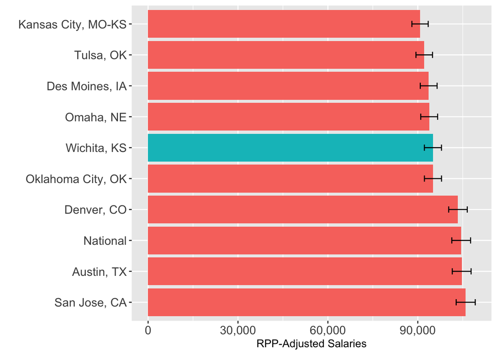

```r
plot_rppAdjustedSalaryByLocation_all
```

(Ideally, nationally, but be careful with applying person-weighted RPPs to developer-weighted average income figures. I.e., if devs tend to live in high RPP areas, using the national RPP doesn’t make sense.)

### Robustness check using Glassdoor

> By Watthana Southivong

#### Methodology

The data was collected through [Glassdoor](https://www.glassdoor.com), which lets an employee and employer to anonymously post a review and work compensation about their company. The data that are collected through Glassdoor in the Wichita area is weak due to the low amount of posting and the data are not updated yearly. It would be hard to make use of the data but it still provides base knowledge to know how much each developer are being compensated.

While not ideal, we can make an assumption that job salary does not increase significantly from each year.The data is collected through searches for “software developer”, “web developer”, and “ computer programmer” with restriction to only Wichita, Kansas. Only compensation update that is from 2016 to 2018 are being collected. The Industry, company size, and the year of experience are the variable that is not set. The companies name, job title, base salary, highest paid salary, additional benefit, month and year that data are updated, and respondent number are collected to an [excel sheet](https://drive.google.com/file/d/1_Ox_UxgYD5NVaoTH6uF-mi2mZfmcT7TU/view?usp=sharing).

#### Data aggregation

The role is compiled into high skills and non-high skills. There is no defined set to skills style but we can make an assumption that the higher skills worker will get compensated more, therefore, it needs to be in its own categories. The high skill is comprised of roles that include senior and manager. The other will be listed as a non-high skill. The average compensation with high skills job level is $114,500. The average compensation without high skills job level is $67,000. The combined compensation average is $73,500. The data for the average with high skills is difficult to analyze since 2017 does not contain any high skill data at all. We also have to take the data with a grain of salt since the data for each year were taken from different companies that control a different portion of the market.

|  | High skills | Low skills | Total Average |
| --- | --- | --- | --- |
| Salary | $114,500 | $67,000 | $73,500 |
| # Data Points | 3 | 19 | 22 |

## Footnotes

[^1]: Direct correspondence with Bureau of Labor Statistics staff economist (May 24, 2019)
[^2]: As a robustness check, the job category list was expanded to include an additional four categories. Wichita compared less favorably in this check. The mean annual salary was also within 2.5% of the 2018 Salary Survey results.